# QAC307 Final

Kathleen Cimino

This study explores the relationship between memes and problem solving. This experiment studied if priming a participant with memes affects the time required to solve puzzles related to the memes.

The sample consisted of 13 people who were in college or recently graduated. Eight were current Wesleyan students, two had graduated the semester before from Wesleyan, and the remaining three were current students at other institutions. They all self-selected to be part of the study after receiving information about the study from various group chats the researcher was in. The participants were assigned to two groups, which determined which memes they were sent. Each participant was sent five memes the day prior to the session. Both groups had two memes in common, which were hints for the first two group puzzles. The other three memes were hints to help solve two of the four riddles they would be sent. Participants began in a zoom group call, where they participated in a LARP, solving puzzles together and roleplaying. As the LARP went on, participants would be asked to mute their computer and also mute their mic and then would be sent a puzzle to solve on their own. Once they successfully solved it and sent the correct answer to the researcher, they would be told to come back to the group call. This occurred four times for each participant. The data was collected during four sessions, which took place over one week.

Priming group was randomly assigned using R with session as a blocking factor.

```r
#Survival Analysis

#create an object for the survfit function (+ means censored data)

surv_object <- Surv(time = data$Time, event = data$Solved)

#fit the curve
fit1 <- survfit(surv_object ~ primed, data = data)
summary(fit1)
```

```
## Call: survfit(formula = surv_object ~ primed, data = data)
##
##                 primed=0
##  time n.risk n.event survival std.err lower 95% CI upper 95% CI
##     6     26       1    0.962  0.0377        0.890        1.000
##    12     25       1    0.923  0.0523        0.826        1.000
##    15     24       1    0.885  0.0627        0.770        1.000
##    29     23       2    0.808  0.0773        0.670        0.974
##    40     21       1    0.769  0.0826        0.623        0.949
##    45     20       1    0.731  0.0870        0.579        0.923
##    46     19       1    0.692  0.0905        0.536        0.895
##    78     18       1    0.654  0.0933        0.494        0.865
##    84     17       1    0.615  0.0954        0.454        0.834
##    91     16       1    0.577  0.0969        0.415        0.802
##   119     15       1    0.538  0.0978        0.377        0.769
```

[output cut: 34 more lines]

```r
survdiff(Surv(Time, Solved)~primed, data=data, rho=0)
```

```
## Call:
## survdiff(formula = Surv(Time, Solved) ~ primed, data = data,
##     rho = 0)
##
##           N Observed Expected (O-E)^2/E (O-E)^2/V
## primed=0 26       19     23.9      1.01      2.35
## primed=1 26       24     19.1      1.27      2.35
##
##  Chisq= 2.4  on 1 degrees of freedom, p= 0.1
```

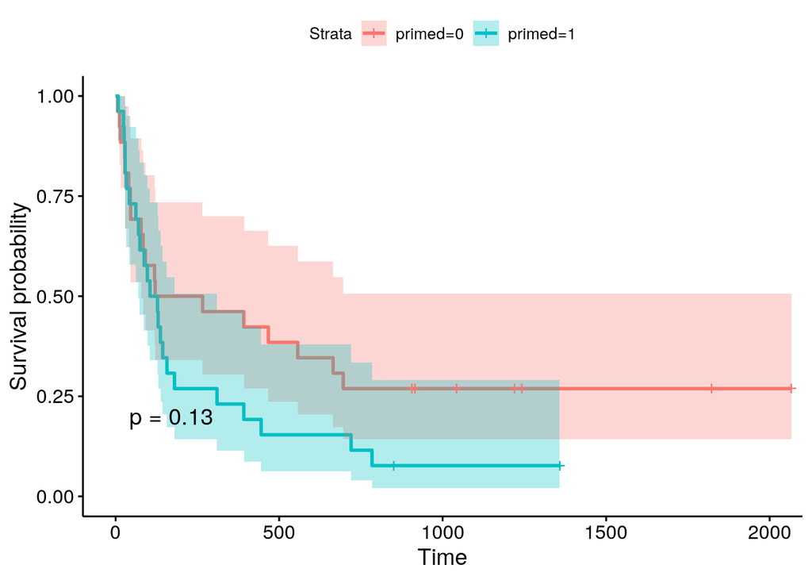

```r
#Plot the data

ggsurvplot(fit1, data = data, pval = TRUE, conf.int=TRUE)
```

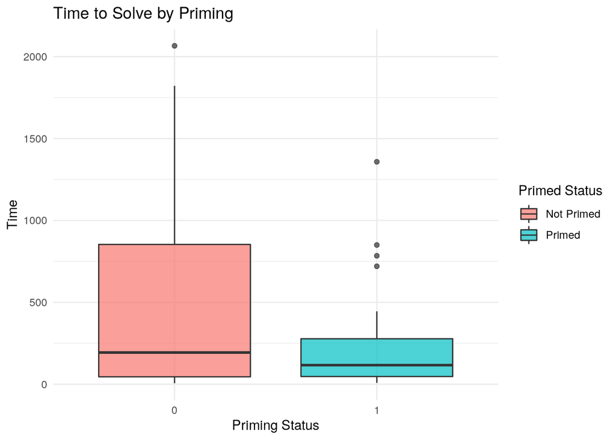

```r
#Plot the data

ggplot(data, aes(x = factor(primed),
                 fill=factor(primed),
                 y = Time)) +
  geom_boxplot(
    alpha = .7) +
  labs(title = "Time to Solve by Priming",
       x="Priming Status")+
  theme_minimal()+
  scale_fill_discrete(name= "Primed Status",
                      labels=c("Not Primed", "Primed"))
```

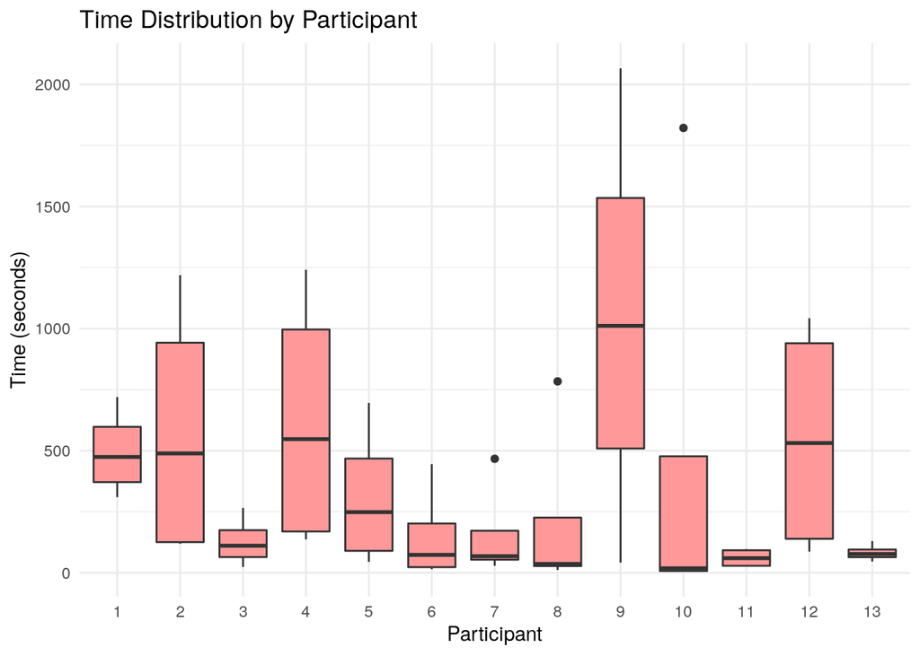

```r
plotdata <- data %>%
  group_by(Participant) %>%
  summarize(mean_Time = mean(Time))
ggplot(data, aes(x = as.factor(Participant),
                 y = Time)) +
  geom_boxplot(fill="#FF9999") +
  labs(title = "Time Distribution by Participant",
       y="Time (seconds)",
       x="Participant")+
  theme_minimal()
```

[figure not shown]

```r
ggplot(data,
       aes(x = as.factor(Riddle),
           fill = as.factor(Solved))) +
  geom_bar(position = "stack")+
  labs(
    title="Solve Rate by Riddle and Priming Status",
    x="Riddle")+
  theme_minimal()+
  scale_fill_discrete(name= "Primed Status",
                      labels=c("Primed", "Not Primed"))
```

If this study were to be conducted at a larger sample size, there are two primary things that could be improved. Determining a participant’s meme literacy and using that as a blocking factor would likely be valuable as there was a clear difference among participants’ ability to solve puzzles. In addition, standardizing the difficulty of the riddles to ensure results are not skewed by the difficulty or type of the riddles could prevent problems caused by differing difficulties of puzzles.